# act_report (1)

## Act Report

### Insights

1. The below pie chart shows that twitter for Iphone is the source with the highest tweet data. Note that this is not to say that this is completely without question as there could be other factors such as content that might contribute to twitter for Iphone being the major tweet source.

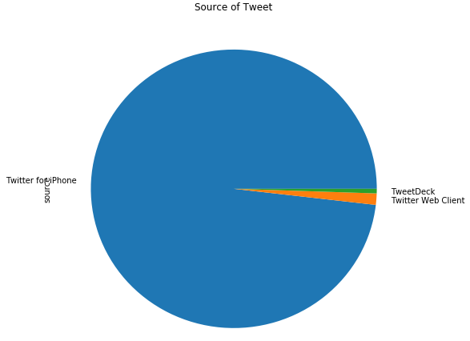

1. The below scatter plot shows the correlation between retweets and favorite count(likes). There is a positive relation between likes and retweets as we can tell from the plot that tweets with more likes are more likely to get more retweets. This is to say as more retweets happen to posts made on @WeRateDogs, there will be more likes. This is also not to imply that there is causability.

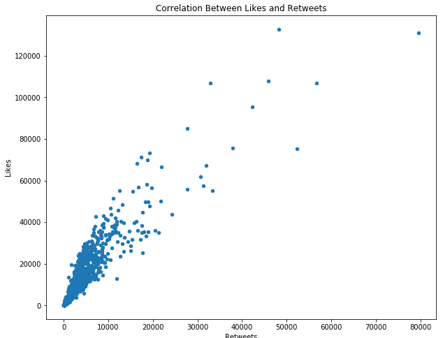

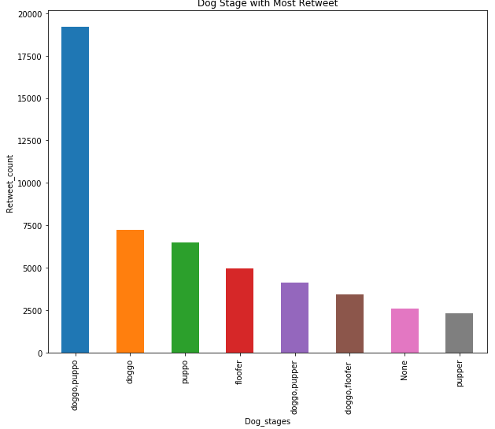

1. In the above comparison of retweets and dog stages, we saw that there are more retweets on the doggo,puppo stage. In the below comparison between favorite_count(likes) and dog stages, there are over 40000 likes for doggo,puppo stage. So we can say that to get more likes and retweets on their page, @weratedogs might need to post more doggo,puppo images.

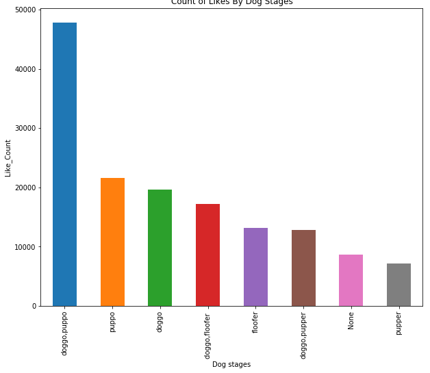

#### Limitations

1. Although there seems to be a correlation between likes and retweets, I am unable to confirm causation.
1. I intially had four sources of tweets which was reduced to three during the cleaning stages.
1. I am unable to confirm if type of phone has a directly correlation to retweet and favorite count(like)
1. In the course of cleaning, a particular source "Vine: make a scene" was eliminated and as such, the analysis done is just a representation of a total sample collection.